# Statistik fuer Biologie FS 2026

## Exercise 17

We first calculate the mean for each genotype:

```r
stickleback = read.csv("~/Dropbox/Teaching/StatisticsForBiology/chap03e3SticklebackPlates.csv")

mean.mm = mean(stickleback$plates[stickleback$genotype=="mm"])
mean.Mm = mean(stickleback$plates[stickleback$genotype=="Mm"])
mean.MM = mean(stickleback$plates[stickleback$genotype=="MM"])
```

Next we do teh same thing for the standard deviation:

```r
sd.mm = sd(stickleback$plates[stickleback$genotype=="mm"])
sd.Mm = sd(stickleback$plates[stickleback$genotype=="Mm"])
sd.MM = sd(stickleback$plates[stickleback$genotype=="MM"])
```

And now we can make 3 plots, one fore each case:

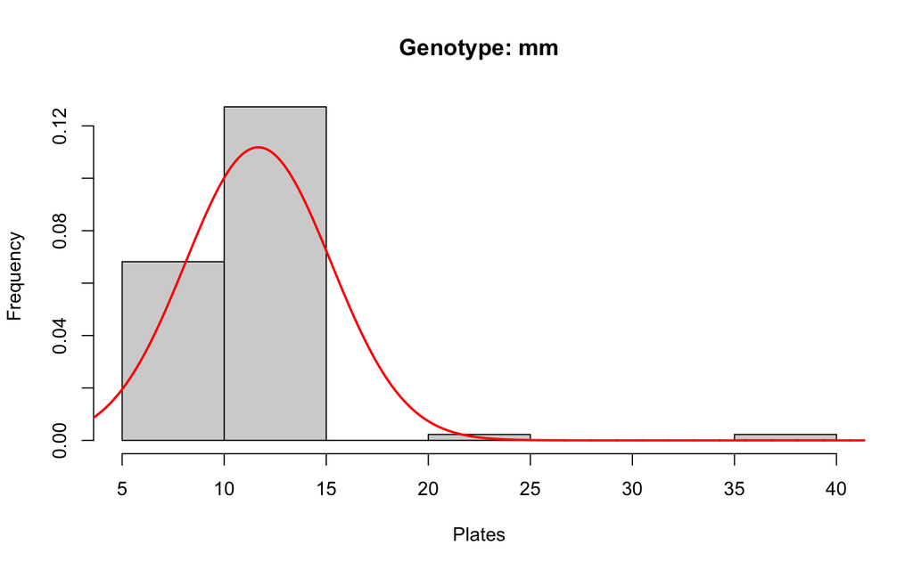

```r
x = seq(0,100,by = 0.01)

hist(stickleback$plates[stickleback$genotype=="mm"],freq=F,
     main =  "Genotype: mm",xlab = "Plates",ylab  = "Frequency ")
y = dnorm(x,mean.mm,sd.mm)
lines(x,y,lwd=2,col="red")
```

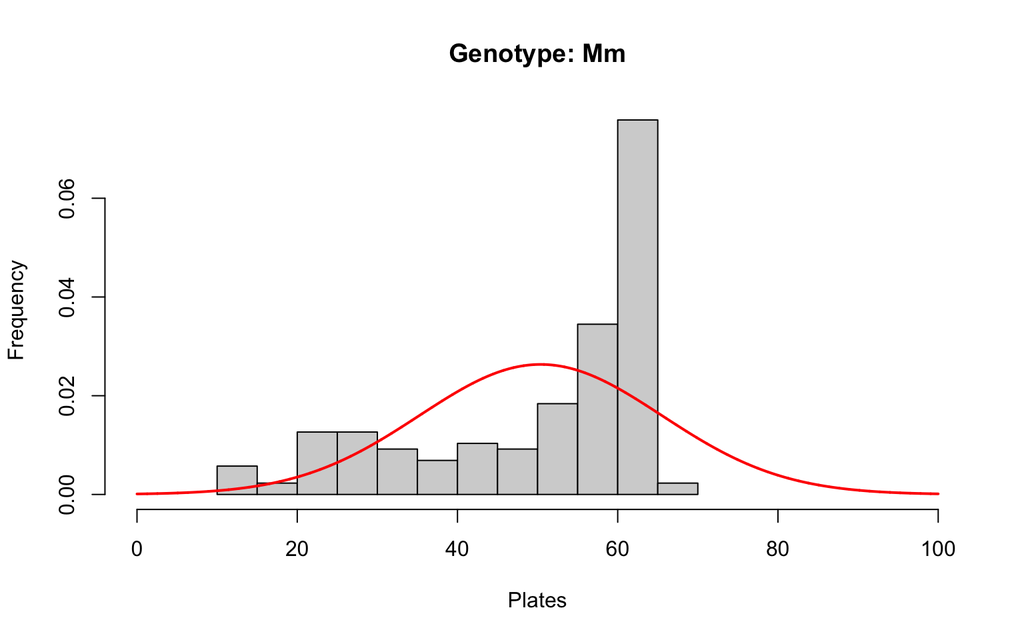

```r
hist(stickleback$plates[stickleback$genotype=="Mm"],freq=F,
     main =  "Genotype: Mm",xlab = "Plates",ylab  = "Frequency ",
     xlim=c(0,100))
y = dnorm(x,mean.Mm,sd.Mm)
lines(x,y,lwd=2,col="red")
```

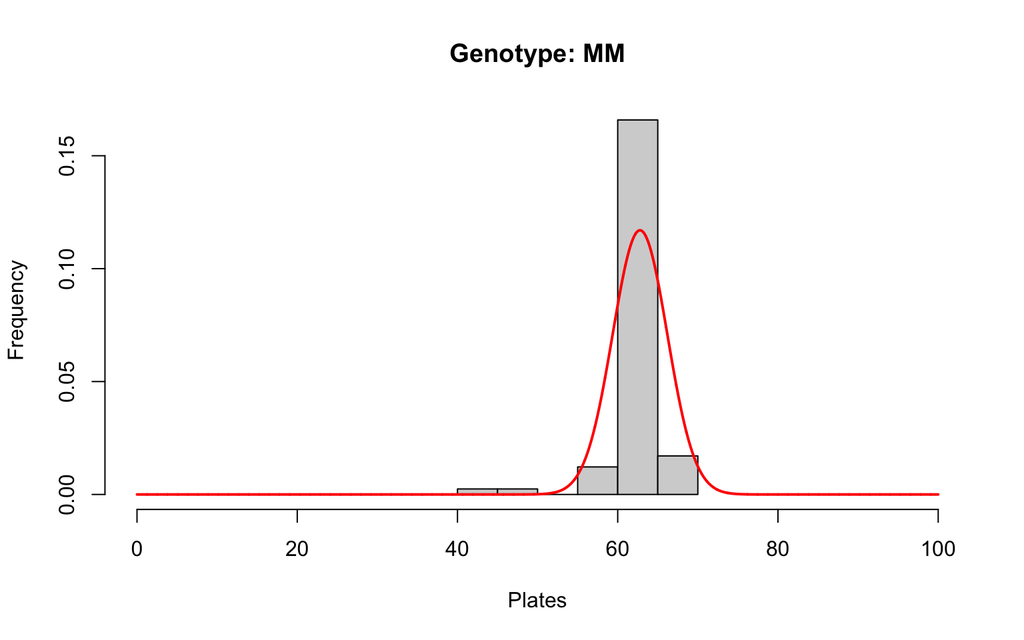

```r
hist(stickleback$plates[stickleback$genotype=="MM"],freq=F,
     main =  "Genotype: MM",xlab = "Plates",ylab  = "Frequency ",
     xlim=c(0,100))
y = dnorm(x,mean.MM,sd.MM)
lines(x,y,lwd=2,col="red")
```

It can be seen clearly from the images that the normal distribution is not a very good approximation to reality in this case. In particular for heterozygotes.

2. We use the function t.test to calculate the upper and lower limit of the 95% CI:

```r
t.t.mm = t.test(stickleback$plates[stickleback$genotype=="mm"])
t.t.Mm = t.test(stickleback$plates[stickleback$genotype=="Mm"])
t.t.MM = t.test(stickleback$plates[stickleback$genotype=="MM"])

CI.mm = t.t.mm$conf.int
CI.Mm = t.t.Mm$conf.int
CI.MM = t.t.MM$conf.int
```

We put it all in a dataframe to make comparison easier:

```r
df = data.frame(means = c(mean.mm,mean.Mm,mean.MM),
                lower = c(CI.mm[1],CI.Mm[1],CI.MM[1]),
                upper = c(CI.mm[2],CI.Mm[2],CI.MM[2]),
                genotypes = c("mm","Mm","MM"))
```

Now we calculate the standard error of the mean for each genotype. We can use the standard deviation we have calculated in (a) for this. First we need the sample size for each group:

```r
n.mm = length(stickleback$genotype=="mm")
n.Mm = length(stickleback$genotype=="Mm")
n.MM = length(stickleback$genotype=="MM")
```

Then we can directly calculate the standard error:

```r
SE.mm = sd.mm/(sqrt(n.mm))
SE.Mm = sd.mm/(sqrt(n.Mm))
SE.MM = sd.mm/(sqrt(n.MM))
```

Adding the results to the data frame:

```r
lower.approx = c(mean.mm-2*SE.mm,mean.Mm-2*SE.Mm,mean.MM-2*SE.MM)
upper.approx = c(mean.mm+2*SE.mm,mean.Mm+2*SE.Mm,mean.MM+2*SE.MM)

df.2 = mutate(df, lower.2SE = lower.approx,
              upper.2SE = upper.approx)

print(df.2)
```

```
##      means    lower    upper genotypes lower.2SE upper.2SE
## 1 11.67045 10.91451 12.42640        mm  11.28573  12.05518
## 2 50.37931 48.11287 52.64575        Mm  49.99458  50.76404
## 3 62.78049 62.03116 63.52982        MM  62.39576  63.16521
```

# Week 8

## Exercise 18

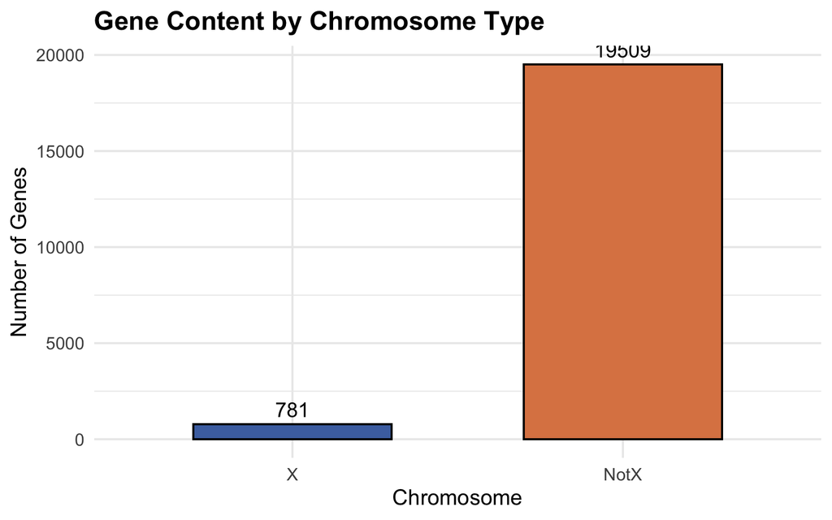

```r
library(ggplot2)
library(dplyr)

geneContent <- read.csv(url("http://whitlockschluter.zoology.ubc.ca/wp-content/data/chapter08/chap08e4XGeneContent.csv"))

geneContent$chromosome <- factor(geneContent$chromosome, levels = c("X","NotX"))

geneContent_df <- geneContent %>%
  dplyr::count(chromosome, name = "Frequency")

ggplot(geneContent_df, aes(x = chromosome, y = Frequency, fill = chromosome)) +
  geom_col(width = 0.6, color = "black") +
  geom_text(aes(label = Frequency), vjust = -0.5, size = 5) +
  scale_fill_manual(values = c("X" = "#4C72B0", "NotX" = "#DD8452")) +
  labs(
    title = "Gene Content by Chromosome Type",
    x = "Chromosome",
    y = "Number of Genes"
  ) +
  theme_minimal(base_size = 15) +
  theme(
    legend.position = "none",
    plot.title = element_text(face = "bold")
  )
```

```r
geneContentTable <- table(geneContent$chromosome)
data.frame(Frequency = (geneContentTable))
```

```
##   Frequency.Var1 Frequency.Freq
## 1              X            781
## 2           NotX          19509
```

```r
chisq.test( geneContentTable, p = c(1055, 19235)/20290 )
```

```
##
##  Chi-squared test for given probabilities
##
## data:  geneContentTable
## X-squared = 75.065, df = 1, p-value < 2.2e-16
```

```r
library(binom)
binom.confint(781, n = 20290, method = "ac")
```

```
##          method   x     n       mean      lower      upper
## 1 agresti-coull 781 20290 0.03849187 0.03592951 0.04122894
```

```r
1055/20290
```

```
## [1] 0.05199606
```

Intepretation:

Our tests shows that there is a very small $p-value$ indicating that the null hypothesis

$H_0:$ The proportion of genes on the X-chromomose is the same as the proportion of base pairs on the X-Chromosome.

can be rejected in favor of the alternative hypothesis

$H_A:$ The proportion of genes on the X-chromomose is not the same as the proportion of base pairs on the X-Chromosome.

## Exercise 19

```r
birthDay <- read.csv(url("http://whitlockschluter.zoology.ubc.ca/wp-content/data/chapter08/chap08e1DayOfBirth.csv"))
head(birthDay)
```

```
##      day
## 1 Sunday
## 2 Sunday
## 3 Sunday
## 4 Sunday
## 5 Sunday
## 6 Sunday
```

Put the days of the week in the correct order for tables and graphs.

```r
birthDay$day <- factor(birthDay$day, levels = c( "Monday",
    "Tuesday", "Wednesday","Thursday","Friday","Saturday","Sunday"))

birthDayTable <- table(birthDay$day)
data.frame(Frequency = addmargins(birthDayTable))
```

```
##   Frequency.Var1 Frequency.Freq
## 1         Monday             41
## 2        Tuesday             63
## 3      Wednesday             63
## 4       Thursday             47
## 5         Friday             56
## 6       Saturday             47
## 7         Sunday             33
## 8            Sum            350
```

Bar graph of the birth data. The argument cex.names = 0.8 shrinks the names of the weekdays to 80% of the default size so that they fit in the graphics window – otherwise one or more names may be dropped.

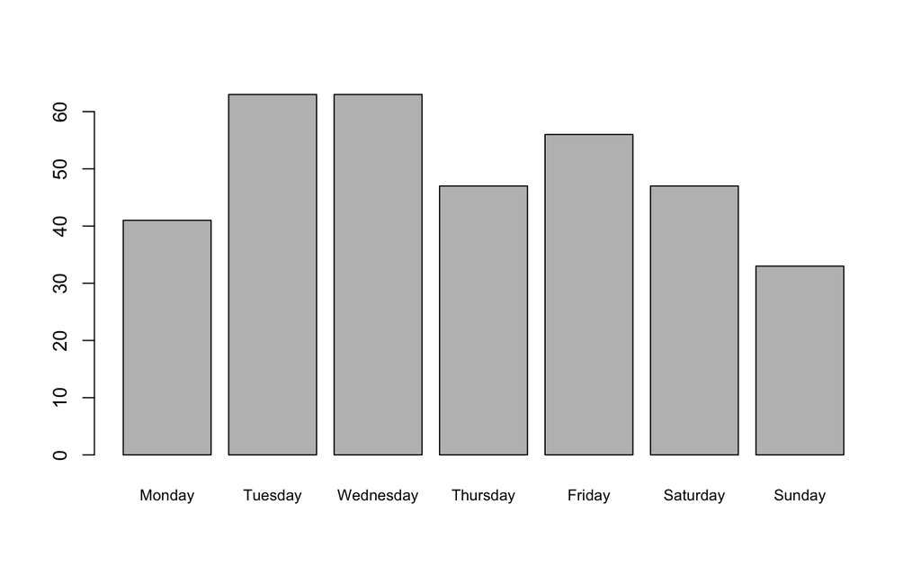

```r
barplot(birthDayTable, cex.names = 0.8)
```

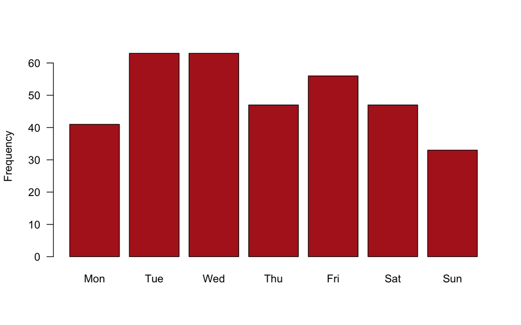

```r
shortNames = substr(names(birthDayTable), 1, 3)
barplot(table(birthDay$day), names = shortNames,
ylab = "Frequency", las = 1, col = "firebrick")
```

$\chi^2$ goodness-of-fit test. The vector p is the expected proportions rather than the expected frequencies, and they must sum to 1 (R nevertheless uses the expected frequencies when calculating the test statistic).

```r
chisq.test(birthDayTable, p = rep(1/7,times=7))
```

```
##
##  Chi-squared test for given probabilities
##
## data:  birthDayTable
## X-squared = 15.24, df = 6, p-value = 0.01847
```

We find a small $p-value$ (< 0.05) so we can rejected the null hypothesis

$H_0: $ birthdays are uniformly distributed across weekdays.

in favor of the alternative hypothesis

$H_A: $ birthdays are not uniformly distributed across weekdays.

From inspecting tha data, it appears as if births are less common on Sundays. It could be that scheduled caesarean deliveries are not scheduled on weekends. Another reason could be that hospitals may sometimes be understaffed on weekends and hence there might be a tendency to wait a bit longer with inducing labor in some non-critical cases.

Note, however, that the p-value is not extremely small. We would reject the null hypothesis if we choose $\alpha = 0.05$ but not if we chosse $\alpha = 0.01$. This illustrates that your choice of rejecting or not rejecting a null hypothesis is strongly influenced by the degree of certainty you want to have in your decision.

# Week 9

## Exercise 20

```r
stalkie <- read.csv(url("http://www.zoology.ubc.ca/~schluter/WhitlockSchluter/wp-content/data/chapter11/chap11e2Stalkies.csv"))
```

We first transform the data to a standard normal distribution. WE achieve this by subtracting the mean (to get a mean of 0) and then dividing by the standard deviation. The latter is essentially changing the “unit” to standard deviations - as an analogy think of going from centimeters to meters: you divide by 100 because 1 meter = 100 cm.

```r
M <- mean(stalkie$eyespan)
sigma <- sd(stalkie$eyespan)

z = (stalkie$eyespan -M)/sigma

print(z)
```

```
## [1] -0.22037998 -1.57613533  1.18558852  1.68772013  0.45749769 -0.32080631
## [7] -0.87315108  0.03068582 -0.37101947
```

```r
print(round(mean(z)),digits = 10)
```

```
## [1] 0
```

```r
print(sd(z))
```

```
## [1] 1
```

Next we do the same thing, except that now we measure the distance from the mean of the bull hypothesis (9 mm) in units of standard errors:

```r
m0 = 9
n <- length(stalkie$eyespan)

SE <- sigma / sqrt(n)
test.statistic <- (M - m0) / SE
print(test.statistic)
```

```
## [1] -1.673772
```

This means that the test statistic is approximately 1.7 standard errors smaller than the mean in the null hypothesis. Is this a lot or not? We can get a better understanding of this by calculating the p-value and illustrating our result:

```r
p.value = 2 * pt(-abs(test.statistic),df=8)
print(p.value)
```

```
## [1] 0.1327105
```

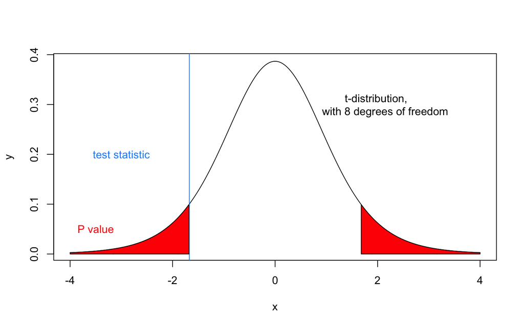

```r
x=seq(-4,4,by=0.01)
y = dt(x,df=8)
plot(x,y,type="l")

abline(v = test.statistic,col="dodgerblue")
text(-3,0.2,"test statistic",col="dodgerblue")
text(2,0.3,"t-distribution,
     with 8 degrees of freedom")

x1 = seq(-4,test.statistic,by=0.01)
y1 = dt(x1,df=8)

x2 = rev(x1)
y2 = y1*0

polygon(c(x1,x2),c(y1,y2),col = "red")
polygon(-c(x1,x2),c(y1,y2),col = "red")
text(-3.5,0.05,"P value",col="red")
```

For comaprison: the p value obtained using the t-test function:

```r
test = t.test(stalkie$eyespan-9)

print(test$p.value)
```

```
## [1] 0.1327105
```

and the test statistic is

```r
print(test$statistic)
```

```
##         t
## -1.673772
```

We can summarize this in a table:

```r
dat = data.frame(pValues = c(p.value,test$p.value),tStatistics = c(test.statistic,test$statistic))
colnames(dat) = c("P Value","Test Statistic")
rownames(dat) = c("by hand","using t.test()")
kableExtra::kable(dat)
```

|  | P Value | Test Statistic |
| --- | --- | --- |
| by hand | 0.1327105 | -1.673772 |
| using t.test() | 0.1327105 | -1.673772 |

## Exercise 21

```r
data = c(58.9, 7.8, 108.6, 44.8, 11.1, 19.2, 61.9, 30.5, 12.7, 35.8, 7.4, 39.3, 24.0, 62.1, 24.3, 55.3, 32.7, 65.3, -19.3, 7.6, -5.2, -2.1, 31.0, 69.0, 88.6, 39.5, 20.7, 89.0, 69.0, 64.9, 64.8)
```

1. What is the sample size n?

```r
n = length(data)

print(paste("The sample size is ",n))
```

```
## [1] "The sample size is  31"
```

2. What is the mean of these data points? Remember to give the units.

```r
m = mean(data)

print(paste("The mean shift is ",m, "meters."))
```

```
## [1] "The mean shift is  39.3290322580645 meters."
```

3. What is the standard deviation of elevational range shift? (Give the units as well.)

```r
sd = sd(data)

print(paste("The staandard deviation of the shift is ",round(sd,digits=2)," meters."))
```

```
## [1] "The staandard deviation of the shift is  30.66  meters."
```

4. What is the standard error of the mean for these data?

```r
SE = sd/sqrt(n)

print(paste("The standard error of the mean is ",round(SE,digits=2),"."))
```

```
## [1] "The standard error of the mean is  5.51 ."
```

5. How many degrees of freedom will be associated with a confidence interval and a one-sample t-test for the mean elevation shift?

There are 30 (= $n-1$) degrees of freedom.

We can check with the t.test() function:

```r
tt = t.test(data)
tt
```

```
##
##  One Sample t-test
##
## data:  data
## t = 7.1413, df = 30, p-value = 6.057e-08
## alternative hypothesis: true mean is not equal to 0
## 95 percent confidence interval:
##  28.08171 50.57635
## sample estimates:
## mean of x
##  39.32903
```

6. Calculate the 95 % confidence interval for the mean using these data.

We can either use our results from the t-test before:

```r
tt$conf.int
```

```
## [1] 28.08171 50.57635
## attr(,"conf.level")
## [1] 0.95
```

or

```r
upper = m + 2*SE
lower = m - 2*SE

c(lower,upper)
```

```
## [1] 28.31452 50.34355
```

A more precise version:

```r
upper = m + qt(0.975,df = n - 1)*SE
lower = m + qt(0.025,df = n - 1)*SE
c(lower,upper)
```

```
## [1] 28.08171 50.57635
```

7. For the one-sample t-test, write down the appropriate null and alternative hypotheses.

$H_0:$ The mean elevational shift is 0 meters. $H_A:$ The mean elevational shift is not 0 meters.

8. Calculate the test statistic t for this test.

We canu again just use t.test():

```r
tt$statistic
```

```
##        t
## 7.141309
```

or do it by hand:

```r
mu.0 = 0 # as specified in the null hypothesis
t.stat = (m - mu.0)/SE
t.stat
```

```
## [1] 7.141309
```

1. What assumptions are necessary to do a one-sample t-test?

The data should be approximately normally distributed. We can check this with a histogram

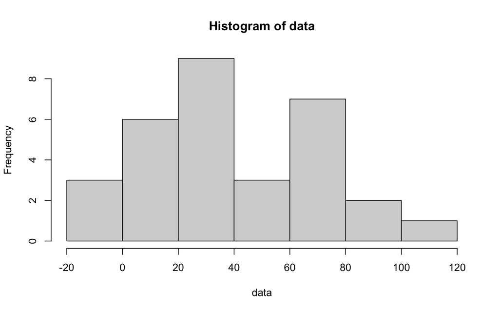

```r
hist(data)
```

A slightly more precise way would be to do a QQ plot

```r
library(car)
```

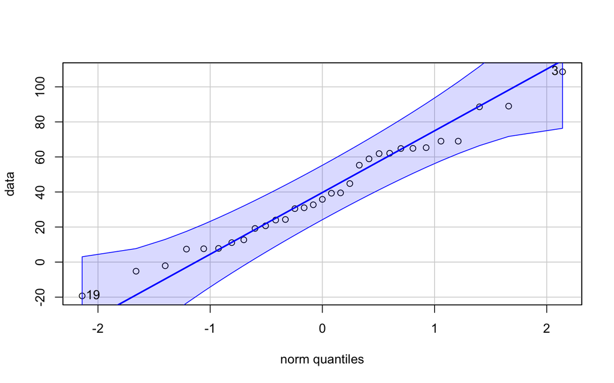

```
## [1]  3 19
```

```r
qqPlot(data)
```

# Week 10

## Exercise 22

10. Calculate the P-value for this test as accurately as you can.

The most accurate way is either to use t-test again

```r
tt$p.value
```

```
## [1] 6.056689e-08
```

We can also do it by hand. For this it is good to make a sketch first:

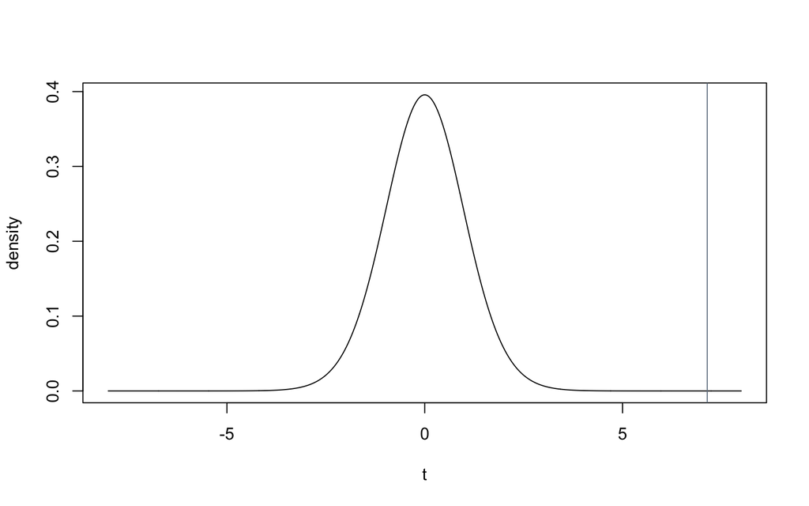

```r
# we first calcualte the null distirbution of our t statisitc
x = seq(-8,8,by=0.01)
y = dt(x,df = n-1)

# and plot it
plot(x,y,type="l",xlab="t",ylab="density")

# we add the observed t statistic
abline(v = t.stat,col="slategray")
```

We see in the figure that the observed t statistic is far away from the mode of the t distribution. The p value should therfroe be very small. To calculate it, we calcualte the area under the curve to the right of the statistic, and double this value to account for extreme events on the left end of the distirbution (we perform a two-sided test). The function pt would give us the area to the left of the test statistic, so we use 2*(1-pt(t.stat,df = n-1)) to get the p-value:

```r
2*(1-pt(t.stat,df = n-1))
```

```
## [1] 6.056689e-08
```

11. Did species change their highest elevation on average?

We choose a signifcance threshold of 5 percent, i.e., we want to be 95 percent certain that we do not have a false positive. Th p-value is clearly smaller than that. Thus, the t-test shows that there is a statistically significant change in the highest elevation. Because the p-value is so small, we can be very certain of this result as it would alos hold at much lower signifcance thresholds.

## Exercise 23

Previously we used a one sample t-test to calculate the confidence intervals. This test also tested the null hypothesis that the means of each group are 0. If we want to compare means between groups we need to do a two sample t-test:

```r
t.test(stickleback$plates[stickleback$genotype=="mm"],
       stickleback$plates[stickleback$genotype=="Mm"])
```

```
##
##  Welch Two Sample t-test
##
## data:  stickleback$plates[stickleback$genotype == "mm"] and stickleback$plates[stickleback$genotype == "Mm"]
## t = -32.001, df = 208.06, p-value < 2.2e-16
## alternative hypothesis: true difference in means is not equal to 0
## 95 percent confidence interval:
##  -41.09355 -36.32416
## sample estimates:
## mean of x mean of y
##  11.67045  50.37931
```

```r
t.test(stickleback$plates[stickleback$genotype=="mm"],
       stickleback$plates[stickleback$genotype=="MM"])
```

```
##
##  Welch Two Sample t-test
##
## data:  stickleback$plates[stickleback$genotype == "mm"] and stickleback$plates[stickleback$genotype == "MM"]
## t = -95.49, df = 167.89, p-value < 2.2e-16
## alternative hypothesis: true difference in means is not equal to 0
## 95 percent confidence interval:
##  -52.16670 -50.05336
## sample estimates:
## mean of x mean of y
##  11.67045  62.78049
```

```r
t.test(stickleback$plates[stickleback$genotype=="Mm"],
       stickleback$plates[stickleback$genotype=="MM"])
```

```
##
##  Welch Two Sample t-test
##
## data:  stickleback$plates[stickleback$genotype == "Mm"] and stickleback$plates[stickleback$genotype == "MM"]
## t = -10.262, df = 207.1, p-value < 2.2e-16
## alternative hypothesis: true difference in means is not equal to 0
## 95 percent confidence interval:
##  -14.78364 -10.01871
## sample estimates:
## mean of x mean of y
##  50.37931  62.78049
```

We find that all t-test yield a significant result (small p values). This means that the null hypothesis of the mean of two groups being the same can be rejected for all comparisons.

A shorter way is by using the function pairwise.t.tests. The First argument is the variable on which the t-test should be performed. The second parameters is the grouping factor: the categorical variable that separates the first argument into different groups.

```r
 pairwise.t.test(stickleback$plates,stickleback$genotype)
```

```
##
##  Pairwise comparisons using t tests with pooled SD
##
## data:  stickleback$plates and stickleback$genotype
##
##    mm      Mm
## Mm < 2e-16 -
## MM < 2e-16 1.5e-15
##
## P value adjustment method: holm
```

How does this finding relate to the confidence intervals? The confidence intervals are not overlapping, strongly suggesting that the means between groups are indeed different (at the 95 percent level). Thus, the t-test and the confidence interval indicate the same result.

# Week 11

## Exercise 24

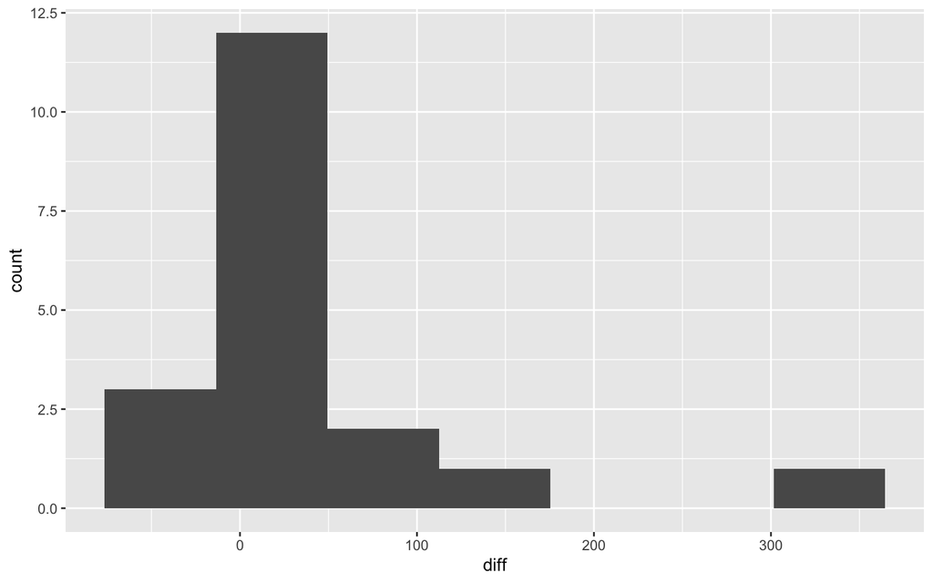

```r
mouse_cooling <- read.csv("~/Dropbox/Teaching/StatisticsForBiology/mouse_cooling.csv")

mouse_cooling = mutate(mouse_cooling,diff = freshly.killed - reheated)
ggplot(mouse_cooling) +
  geom_histogram(aes(x = diff),bins=7)
```

The data is clearly right skewed. This can also be seen with a QQ plot:

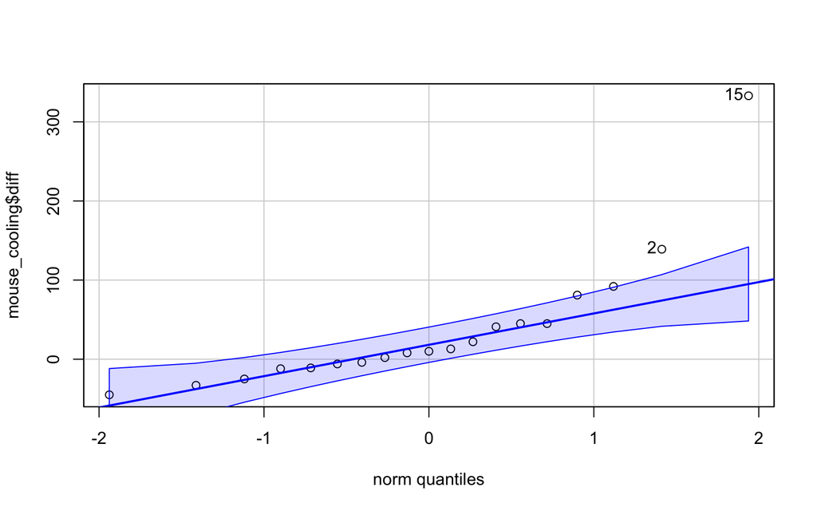

```
## [1] 15  2
```

```r
library(car)
qqPlot(mouse_cooling$diff)
```

The null hypothesis is

$H_0:$ The true mean of the differences is $\mu_0 = 0$.

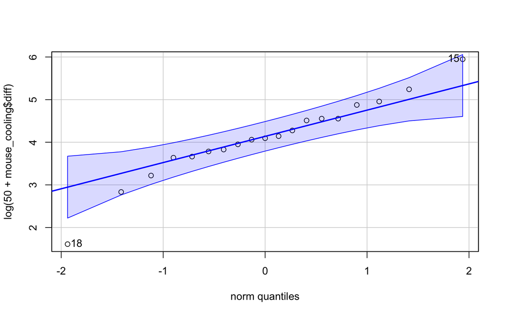

```
## [1] 18 15
```

```r
library(car)
qqPlot(log(50+mouse_cooling$diff))
```

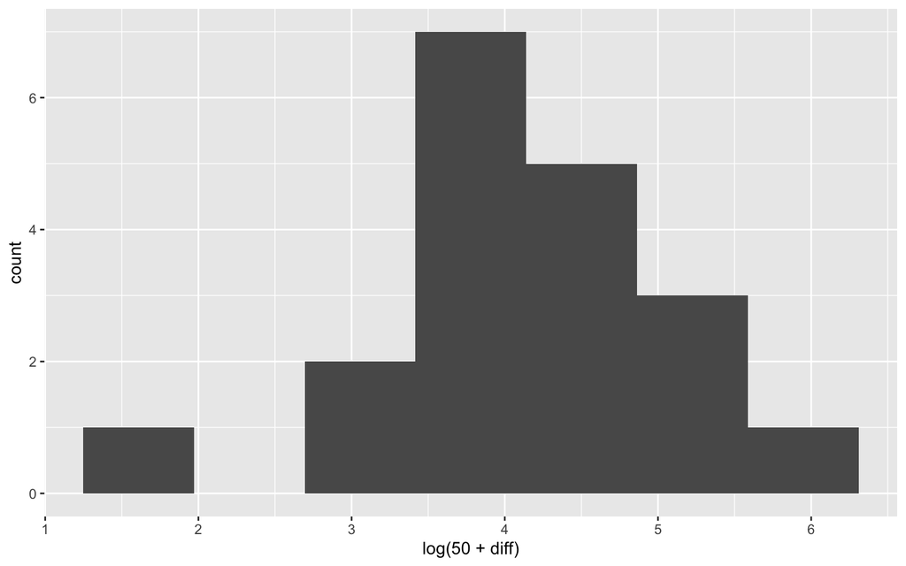

```r
ggplot(mouse_cooling) +
  geom_histogram(aes(x = log(50+diff)),bins=7)
```

This looks much better now and we perform a t-test on these data:

```r
results = t.test(log(50+mouse_cooling$diff),mu = log(50))
results
```

```
##
##  One Sample t-test
##
## data:  log(50 + mouse_cooling$diff)
## t = 0.83424, df = 18, p-value = 0.4151
## alternative hypothesis: true mean is not equal to 3.912023
## 95 percent confidence interval:
##  3.639332 4.543906
## sample estimates:
## mean of x
##  4.091619
```

An alternative would be the sign test:

```r
k = sum(mouse_cooling$diff<0)
results.sign = binom.test(k,n=19,p=0.5)
results.sign
```

```
##
##  Exact binomial test
##
## data:  k and 19
## number of successes = 7, number of trials = 19, p-value = 0.3593
## alternative hypothesis: true probability of success is not equal to 0.5
## 95 percent confidence interval:
##  0.1628859 0.6164221
## sample estimates:
## probability of success
##              0.3684211
```

In both cases we find no significant devation from 0 in the differnces. We thus cannot reject the null hypothesis.

## Exercise 25

1. $\chi^2$ Goodness of fit test H0: Fish numbers per unit area follow a Poisson distribution.
2. Two sample t-test or a non-parametric alternative. H0: There is no difference in the mean tumor size change in the two groups.
3. One sample t-test or a non-parametric alternative. H0: Themean tumor size change durign the treatment is 0.
4. $\chi^2$ Goodness-of-fit test H0: The number of smokers in a city is proportional to the number of people in that city.
5. One-sample t-test H0: Mean change in patient body mass during hospital stay is zero.

## Exercise 26

```r
health.expenditure <- read.csv("~/Dropbox/Teaching/StatisticsForBiology/health_expenditure.csv")
```

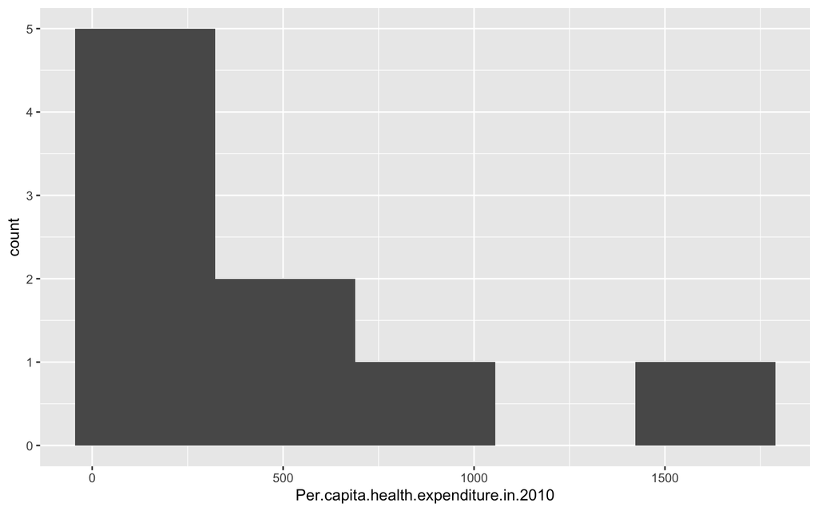

```r
ggplot(health.expenditure) +
  geom_histogram(aes(x = Per.capita.health.expenditure.in.2010),bins=10)
```

Becaue it is highly right skewed.

3. The sample size is

```r
n = dim(health.expenditure)[1]
n
```

```
## [1] 18
```

4. Calculate the natural logarithm of each data point.

```r
data = mutate(health.expenditure,log.expend=  log(Per.capita.health.expenditure.in.2010))
data$log.expend
```

```
##  [1] 6.761573 5.768321 5.476464 6.782192 6.156979 4.276666 4.094345 6.408529
##  [9] 3.850148 5.192957 5.509388 4.691348 7.436617 4.997212 5.888878 4.343805
## [17] 7.305860 6.522093
```

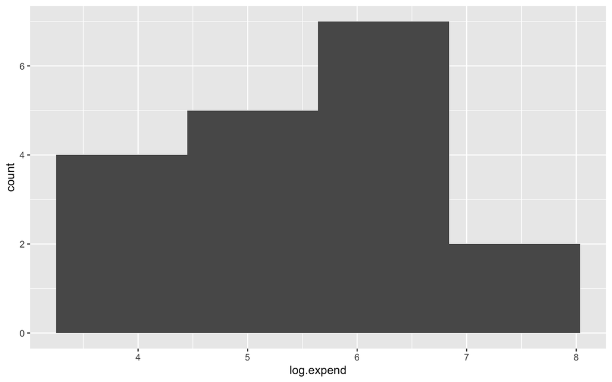

```r
ggplot(data) +
  geom_histogram(aes(x = log.expend),bins=4)
```

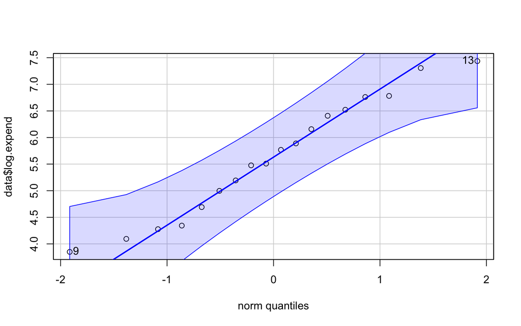

```
## [1] 13  9
```

```r
qqPlot(data$log.expend)
```

5. The mean is

```r
 M =mean(data$log.expend)
M
```

```
## [1] 5.636854
```

6. The standard deviation is

```r
SD = sd(data$log.expend)
SD
```

```
## [1] 1.110587
```

The standard error is

```r
SE = SD/sqrt(n)
SE
```

```
## [1] 0.2617679
```

```r
CI.log = t.test(data$log.expend)$conf.int
CI.log
```

```
## [1] 5.084572 6.189136
## attr(,"conf.level")
## [1] 0.95
```

or alterantively we can approximate it by:

```r
CI.log.app = c(M-2*SE,M+2*SE)
CI.log.app
```

```
## [1] 5.113318 6.160390
```

```r
CI.nonlog = exp(CI.log)
CI.nonlog
```

```
## [1] 161.5108 487.4248
## attr(,"conf.level")
## [1] 0.95
```

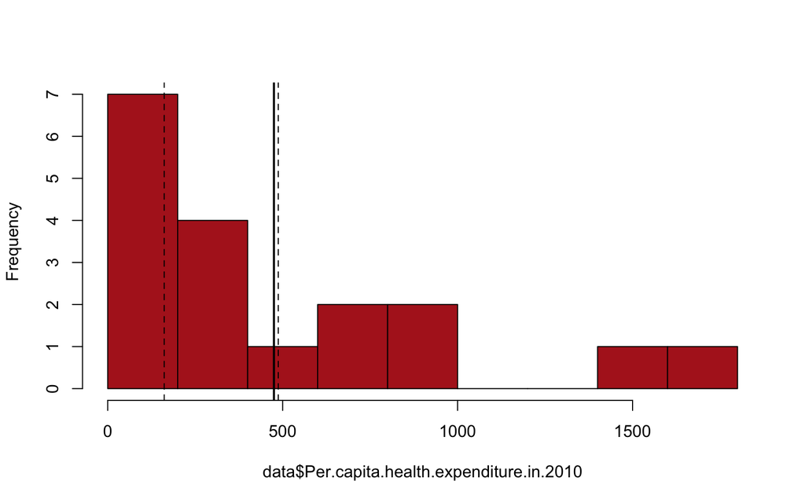

```r
M.nonlog = mean(data$Per.capita.health.expenditure.in.2010)
hist(data$Per.capita.health.expenditure.in.2010,col="firebrick",main="",breaks=10)
abline(v = CI.nonlog,lty=2)
abline(v = M.nonlog,lwd=2)
```

Note how asymmetric the back transformed CI is - this reflects the asymmetry of the data. Be careful however, as this is an approximation! (Note: mean of logarithm transformed data is not the same as the logarithm of the mean of the data).

# Week 12

## Exercise 27

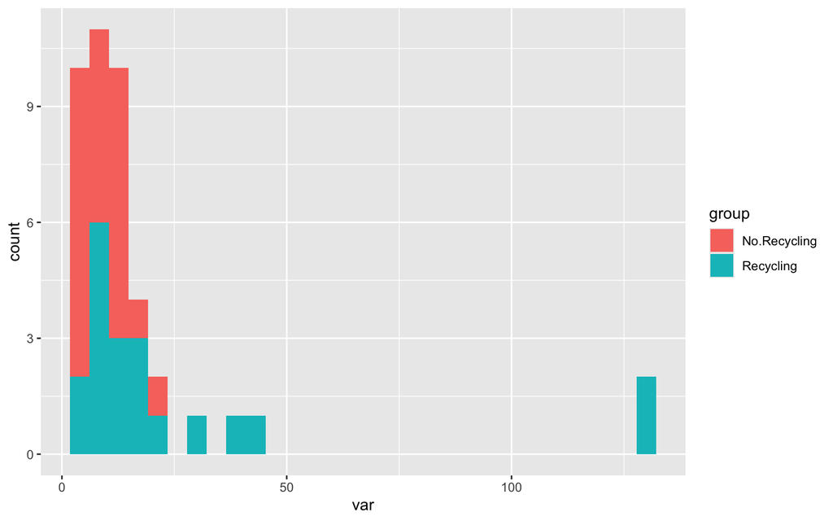

```r
no.recycling = c(4,4,4,4,4,4,4,5,8,9,9,9,9,12,12,13,14,14,14,14,15,23)
recycling = c(4,5,8,8,8,9,9,9,12,14,14,15,16,19,23,28,40,43,129,130)

n.rec = length(recycling)
n.no.rec = length(no.recycling)

group = rep(c("Recycling","No.Recycling"),times=c(n.rec,n.no.rec))

dat = data.frame(var = c(recycling,no.recycling),group = group)

ggplot(dat) +
  geom_histogram(aes(x = var,fill=group))
```

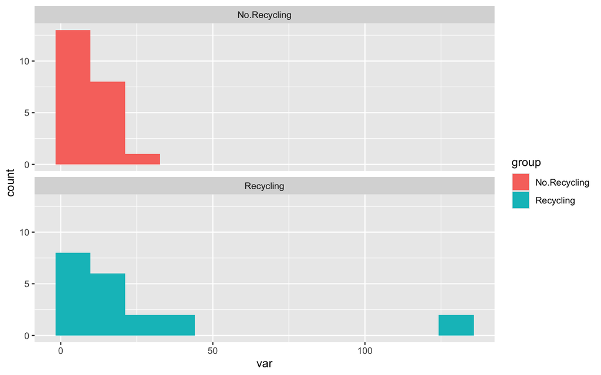

```r
ggplot(dat) +
  geom_histogram(aes(x = var,fill = group),bins=12) +
  facet_wrap(~group,nrow=2)
```

Both shape and spread seem to be different here, altough it is diffcult to tell based on the small sample sice. A Normal Distribution can however be ruled out, especially fro the *recycling group*.

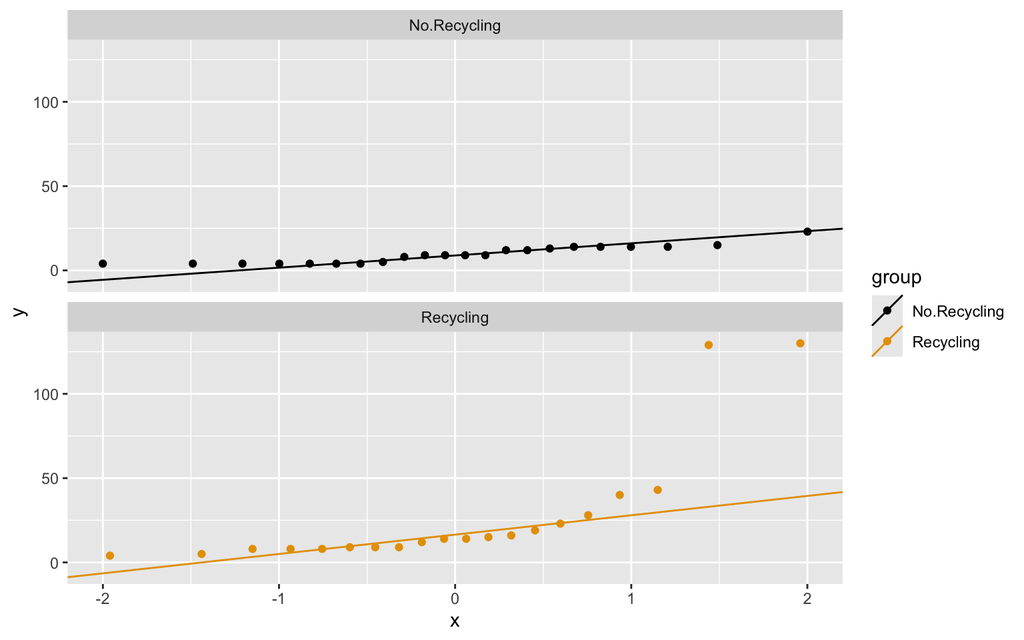

```r
ggplot(dat) +
  geom_qq(aes(sample = var,col=group)) +
  geom_qq_line(aes(sample = var,col=group))+
  facet_wrap(~group,nrow=2)
```

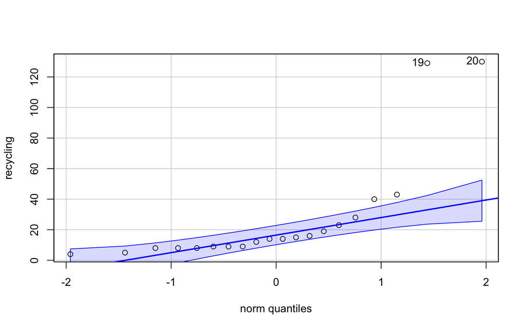

```
## [1] 20 19
```

```r
qqPlot(recycling)
```

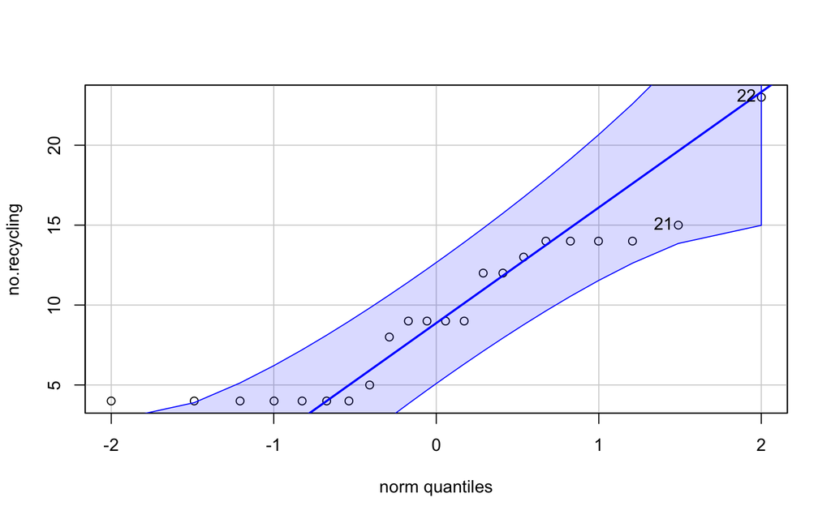

```
## [1] 22 21
```

```r
qqPlot(no.recycling)
```

c and d)

$H_0:$ It is equally likely that a randomly selected value from one group will be less than or greater than a randomly selected value from a second population. $H_A:$ It is not equally likely that a randomly selected value from one group will be less than or greater than a randomly selected value from a second population.

```r
wilcox.test(var~group,data=dat)
```

```
##
##  Wilcoxon rank sum exact test
##
## data:  var by group
## W = 126.5, p-value = 0.01686
## alternative hypothesis: true location shift is not equal to 0
```

```r
# alternative without dataframes
wilcox.test(recycling,no.recycling)
```

```
##
##  Wilcoxon rank sum exact test
##
## data:  recycling and no.recycling
## W = 313.5, p-value = 0.01686
## alternative hypothesis: true location shift is not equal to 0
```

For comparison, a t-test in this case would yield (not taht the t-test uses a different null hypothesis ):

```r
t.test(var~group,data=dat)
```

```
##
##  Welch Two Sample t-test
##
## data:  var by group
## t = -2.1447, df = 19.681, p-value = 0.04465
## alternative hypothesis: true difference in means between group No.Recycling and group Recycling is not equal to 0
## 95 percent confidence interval:
##  -34.9245559  -0.4663532
## sample estimates:
## mean in group No.Recycling    mean in group Recycling
##                   9.454545                  27.150000
```

## Exercise 28

We first calculate the actual difference of the means:

```r
no.recycling = c(4,4,4,4,4,4,4,5,8,9,9,9,9,12,12,13,14,14,14,14,15,23)
recycling = c(4,5,8,8,8,9,9,9,12,14,14,15,16,19,23,28,40,43)

n.rec = length(recycling)
n.no.rec = length(no.recycling)

group = rep(c("Recycling","No.Recycling"),times=c(n.rec,n.no.rec))

dat = data.frame(var = c(recycling,no.recycling),group = group)
MeanR = mean(no.recycling)
MeanNR = mean(recycling)
diffMeans =  MeanNR - MeanR
```

```r
nPerm = 1000
permResult <- vector() # initializes
for(i in 1:nPerm){
    # step 1: permute the group labels
    permSample <- sample(dat$group, replace = FALSE)

    # step 2: calculate difference betweeen means
    permMeanR <-mean(dat$var[permSample=="Recycling"])
    permMeanNR <-mean(dat$var[permSample=="No.Recycling"])
    permResult[i] <- permMeanNR - permMeanR
}
```

Plot null distribution based on the permuted differences.

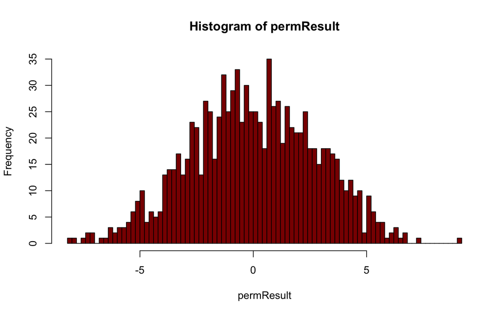

```r
hist(permResult, right = FALSE, breaks = 100,col="darkred")
```

```r
sum(as.numeric(permResult >= diffMeans))
```

```
## [1] 5
```

```r
sum(as.numeric(permResult >= diffMeans)) / nPerm
```

```
## [1] 0.005
```

Finally, multiply by 2 to get the P-value for a two-sided test.

```r
2 * ( sum(as.numeric(permResult > diffMeans)) / nPerm )
```

```
## [1] 0.01
```

We can illustrate the permutaed differences and add the observed difference on to show the outcome of our test: the birght red colored bars indicate the proportion of permutation results that yielded a more exterme results as the one observed.

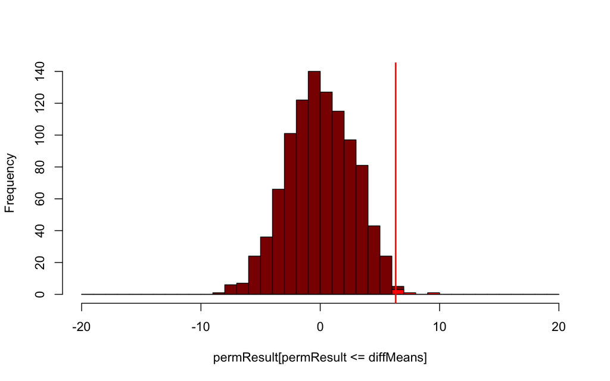

```r
hist(permResult[permResult<=diffMeans],breaks=seq(-20,20,by=1),col="darkred",main="")
hist(permResult[permResult>diffMeans],breaks=seq(-20,20,by=1),add=T,col="red")
abline(v = diffMeans,col="red",lwd=2)
```

An alternative approach is

```r
library(perm)
permTS(dat$var[dat$group=="Recycling"],dat$var[dat$group=="No.Recycling"],exact = T)
```

```
##
##  Exact Permutation Test Estimated by Monte Carlo
##
## data:  GROUP 1 and GROUP 2
## p-value = 0.01
## alternative hypothesis: true mean GROUP 1 - mean GROUP 2 is not equal to 0
## sample estimates:
## mean GROUP 1 - mean GROUP 2
##                    6.323232
##
## p-value estimated from 999 Monte Carlo replications
## 99 percent confidence interval on p-value:
##  0.001347329 0.025105152
```

We again find that we can reject the Null Hypothesis.

# Week 13

## Exercise 29

```r
dom = "http://www.zoology.ubc.ca/"
path = "~schluter/WhitlockSchluter/wp-content/data/"
dat = "chapter15/chap15e1KneesWhoSayNight.csv"
location = paste(dom,path,dat,sep="")
circadian <- read.csv(url(location),stringsAsFactors = FALSE)
```

1. Visualize the data:

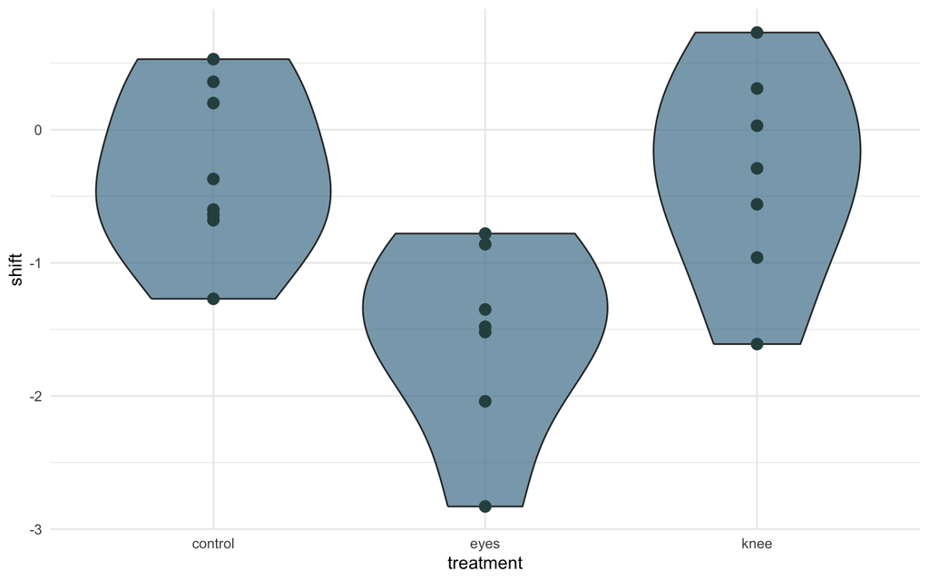

```r
ggplot(data = circadian) +
  geom_violin(aes(x = treatment,
                  y =shift),
              fill=rgb(0.3,0.5,0.6,0.7),
              bw = 0.5) +
  geom_point(aes(x = treatment,y = shift),
             col="darkslategray",size=3) +
  theme_minimal()
```

2. Test for differences in means:

```r
mod = lm(shift ~ treatment,data = circadian)

anova(mod)
```

```
## Analysis of Variance Table
##
## Response: shift
##           Df Sum Sq Mean Sq F value   Pr(>F)
## treatment  2 7.2245  3.6122  7.2894 0.004472 **
## Residuals 19 9.4153  0.4955
## ---
## Signif. codes:  0 '***' 0.001 '**' 0.01 '*' 0.05 '.' 0.1 ' ' 1
```

We find that not all groups have the same mean.

```r
pairwise.t.test(circadian$shift,circadian$treatment)
```

```
##
##  Pairwise comparisons using t tests with pooled SD
##
## data:  circadian$shift and circadian$treatment
##
##      control eyes
## eyes 0.0088  -
## knee 0.9418  0.0088
##
## P value adjustment method: holm
```

We find that the the “eyes” is different from the other two groups, but “knee” is the same as “control”. This can also be seen very well on the plot of the raw data.

4. The new study failed at replicating the older results, which suggested that light treatment behind the knee can alter your circadian rhythm of melatonin production. Light treatment behind the knee indeed has a different effect than light treatment to the eyes. However, inclusion of a control group shows that only light treatment at the eyes showed an effect relative to the control group. This illustrates how important a proper control group is in experimental design. Without a proper control group, it is nearly impossible to determine whether a certain treatment indeed has an effect.

# Week 14

## Exercise 30

Load the data set:

```r
dom = "http://www.zoology.ubc.ca/"
path = "~schluter/WhitlockSchluter/wp-content/data/"
dat = "chapter17/chap17e1LionNoses.csv"
location = paste(dom,path,dat,sep="")
lion <- read.csv(url(location))
head(lion)
```

```
##   proportionBlack ageInYears
## 1            0.21        1.1
## 2            0.14        1.5
## 3            0.11        1.9
## 4            0.13        2.2
## 5            0.12        2.6
## 6            0.13        3.2
```

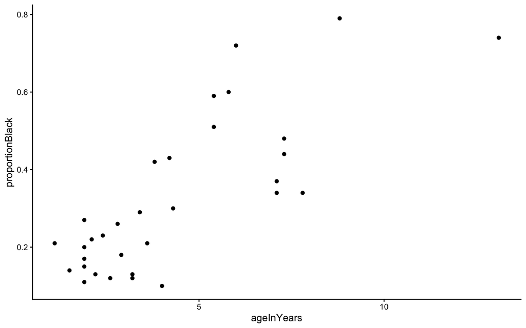

```r
ggplot(data = lion) +
  geom_point(aes(x = ageInYears,y = proportionBlack)) +
  theme_classic()
```

2. The correlation coefficient can be calcualted using the function *cor*:

```r
cor(lion$ageInYears,lion$proportionBlack)
```

```
## [1] 0.7898272
```

```r
model = lm( ageInYears~ proportionBlack,data=lion)
summary(model)
```

```
##
## Call:
## lm(formula = ageInYears ~ proportionBlack, data = lion)
##
## Residuals:
##     Min      1Q  Median      3Q     Max
## -2.5449 -1.1117 -0.5285  0.9635  4.3421
##
## Coefficients:
##                 Estimate Std. Error t value Pr(>|t|)
## (Intercept)       0.8790     0.5688   1.545    0.133
## proportionBlack  10.6471     1.5095   7.053 7.68e-08 ***
## ---
## Signif. codes:  0 '***' 0.001 '**' 0.01 '*' 0.05 '.' 0.1 ' ' 1
##
## Residual standard error: 1.669 on 30 degrees of freedom
## Multiple R-squared:  0.6238, Adjusted R-squared:  0.6113
## F-statistic: 49.75 on 1 and 30 DF,  p-value: 7.677e-08
```

The coefficients of our model are:

```r
print(model$coefficients)
```

```
##     (Intercept) proportionBlack
##       0.8790062      10.6471194
```

The linear model for the regression line is therefore

$$ageInYears = 0.879 + 10.647 *
proportionBlack$$

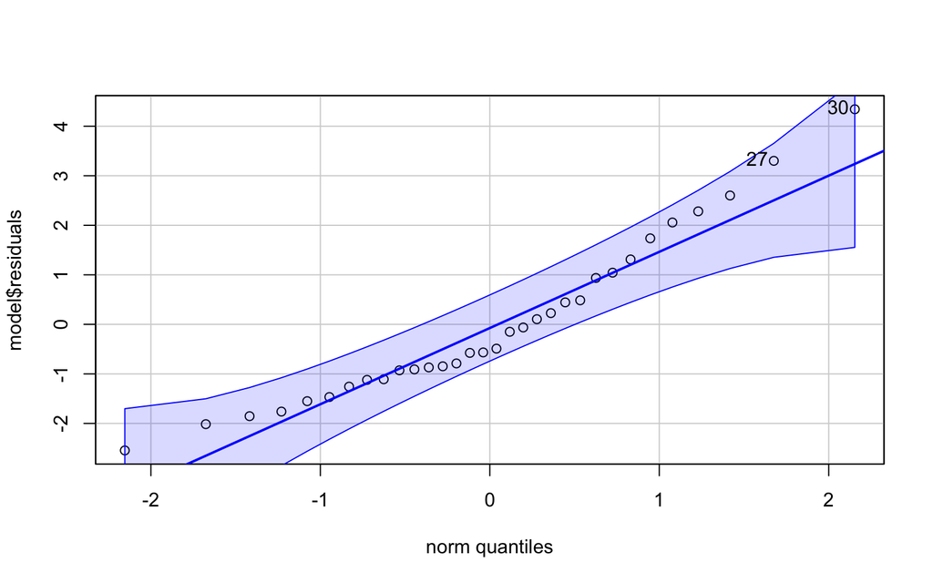

```
## [1] 30 27
```

```r
library(car)
qqPlot(model$residuals,dist="norm")
```

A QQ-plot of the residuals shows that they are normally distributed.

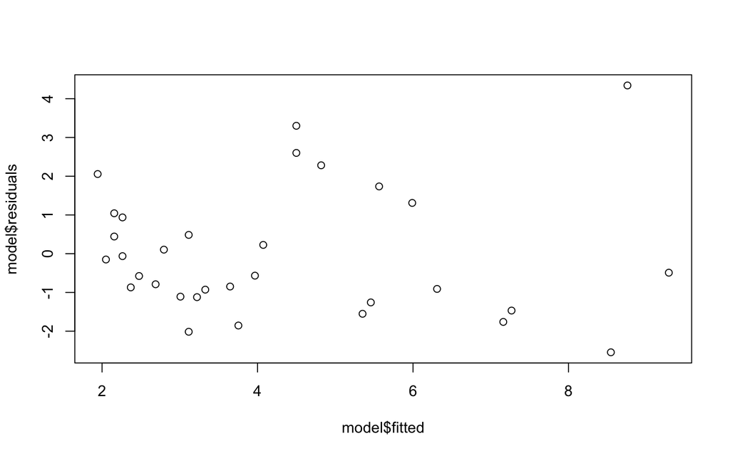

```r
plot(model$fitted,model$residuals)
```

The Tukey-Anscombe plot shows no (strong) deviation from uniform variance of residuals.

We get confindence intervals with the function *confint*:

```r
confint(model)
```

```
##                      2.5 %    97.5 %
## (Intercept)     -0.2826733  2.040686
## proportionBlack  7.5643082 13.729931
```

This can be directly seen from the CIs from (e) or the summary of the model:

```r
summary(model)
```

```
##
## Call:
## lm(formula = ageInYears ~ proportionBlack, data = lion)
##
## Residuals:
##     Min      1Q  Median      3Q     Max
## -2.5449 -1.1117 -0.5285  0.9635  4.3421
##
## Coefficients:
##                 Estimate Std. Error t value Pr(>|t|)
## (Intercept)       0.8790     0.5688   1.545    0.133
## proportionBlack  10.6471     1.5095   7.053 7.68e-08 ***
## ---
## Signif. codes:  0 '***' 0.001 '**' 0.01 '*' 0.05 '.' 0.1 ' ' 1
##
## Residual standard error: 1.669 on 30 degrees of freedom
## Multiple R-squared:  0.6238, Adjusted R-squared:  0.6113
## F-statistic: 49.75 on 1 and 30 DF,  p-value: 7.677e-08
```

The p-value for the null hypothesis that the slope is 0 is very small, $P = 7.7 * 10^-8$. We can therfore reject the null hypothesis that $beta_1 = 0$.

This is easiest using *geom_smooth()* in ggplot:

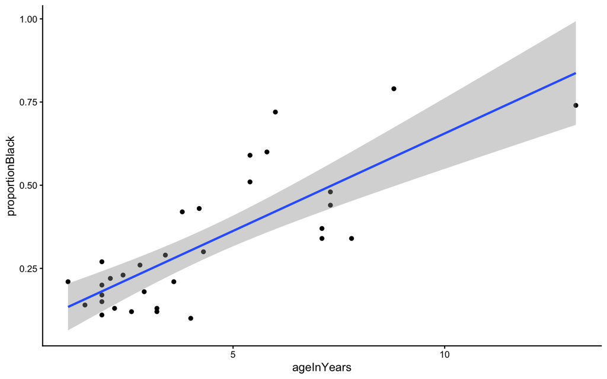

```r
ggplot(data = lion,aes(x = ageInYears,y = proportionBlack)) +
  geom_point() +
  geom_smooth(method = "lm") +
  theme_classic()
```

See what happens when we do not specify the method in *lm()*:

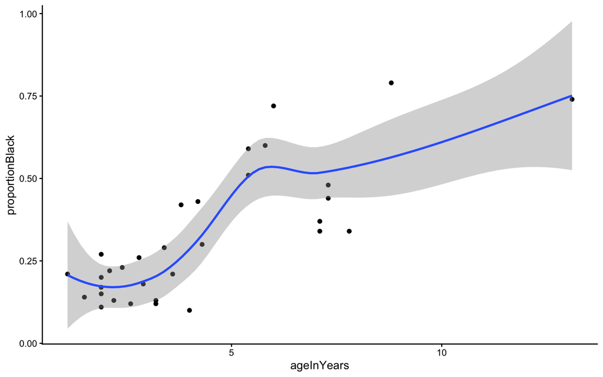

```r
ggplot(data = lion,aes(x = ageInYears,y = proportionBlack)) +
  geom_point() +
  geom_smooth() +
  theme_classic()
```

## Aufgabe 1: Mendelsche Vererbung (Chi-Quadrat Goodness-of-Fit)

**a) Methode:**  
Chi-Quadrat-Test (Goodness-of-Fit)

**R-Funktion:**

```r
chisq.test()
```

**b) Hypothesen:**  
- H₀: Die beobachteten Häufigkeiten folgen dem erwarteten Mendel-Verhältnis (1:2:1)  
- H₁: Die beobachteten Häufigkeiten weichen vom erwarteten Verhältnis ab

**c) Voraussetzung:**  
- Erwartete Häufigkeiten sollten ausreichend groß sein (typisch ≥ 5)

## Aufgabe 2: Medikamenteneffekt auf Enzymaktivität

**a) Methode:**  
Gepaarter t-Test

**R-Funktion:**

```r
t.test(x, y, paired = TRUE)
```

**b) Hypothesen:**  
- H₀: Die mittlere Differenz zwischen vorher und nachher ist 0  
- H₁: Die mittlere Differenz ist ungleich 0

**c) Alternative bei Nicht-Normalität:**  
Wilcoxon Signed-Rank Test

**R-Funktion:**

```r
wilcox.test(x, y, paired = TRUE)
```

## Aufgabe 3: Habitatwahl bei Fischen

**a) Methode:**  
Permutationstest (für gepaarte Differenzen)

**R-Ansatz:**

```r
# z.B. mit coin Paket
coin::oneway_test()
```

oder eigene Implementierung mit replicate()

**b) Begründung:**  
- keine Verteilungsannahme notwendig  
- robust bei kleiner Stichprobe und hoher Varianz

**c) Hypothesen:**  
- H₀: keine Präferenz (Differenz = 0)  
- H₁: Präferenz für ein Habitat (Differenz ≠ 0)

## Aufgabe 4: Stress bei Mäusen

**a) Methode:**  
Einfaktorielle ANOVA

**R-Funktion:**

```r
aov()
```

oder alternativ:

```r
lm()
anova()
```

**b) Warum kein t-Test:**  
- mehr als zwei Gruppen → multiple Vergleiche nötig

**c) Hypothesen:**  
- H₀: alle Gruppenmittelwerte sind gleich  
- H₁: mindestens ein Mittelwert unterscheidet sich

## Aufgabe 5: Düngemittel und Pflanzenwachstum

**a) Methode:**  
Lineare Regression

**R-Funktion:**

```r
lm()
```

**b) Variablen:**  
- unabhängig: Düngermenge  
- abhängig: Pflanzenhöhe

**c) H₀:**  
- Regressionskoeffizient β₁ = 0

**d) Interpretation:**  
- positiver Koeffizient → mehr Dünger erhöht mittleres Wachstum

## Aufgabe 6: Lernverhalten bei Bienen

**a) Methode:**  
Binomialtest oder Chi-Quadrat-Test

**R-Funktionen:**

```r
binom.test()
chisq.test()
```

**b) Alternative:**  
Sign-Test / einfache nichtparametrische Alternative

**R-Funktion:**

```r
binom.test()
```

**c) Hypothesen:**  
- H₀: p = 0.5 (keine Präferenz)  
- H₁: p ≠ 0.5

## Aufgabe 7: Antibiotikum und Bakterienwachstum

**a) Methode:**  
Zweifaktorielle ANOVA

**R-Funktion:**

```r
aov()
lm()
```

**b) Problem:**  
- Varianzhomogenität verletzt → klassische ANOVA problematisch

**c) Alternative:**  
Kruskal-Wallis-Test (ein Faktor) oder permutation-based ANOVA

**R-Funktionen:**

```r
kruskal.test()
coin::oneway_test()
```

## Hinweis

Lineare Modelle können viele dieser Tests vereinheitlichen:

```r
lm(y ~ x)
lm(y ~ group)
```